# Exp2

Jennie

2024-06-14

## Experiment 2

In this experiment, we asked if the presence of a complete artificial honeypot (i.e. a ‘model’) would affect bees’ likelihood of repairing and using an incomplete honeypot.

### 0) Dataset

```r
# load packages
library(tidyverse)
file <- "https://raw.githubusercontent.com/jennieandbird/Honeypots/Data/2024-03-22_Exp2.csv"
exp2data <- read_csv(file)
# Remove any blank entries leftover from the Excel to CSV export.
exp2data <- exp2data |> drop_na(microcolony)
```

#### Explanation of variables:

- **microcolony:** a unique number for each microcolony (001–133) in the dataset.
- **label:** how the microcolonies were labeled during the experiment (e.g., “2.E8” meaning Treatment #2, Colony E, Microcolony #8) and is included in the dataset for ease of data entry.
- **colony:** the bumblebee colony from which worker bees were sourced.
- **incomplete:** the type of incomplete honeypot (½-HP written “0.50”, or ¾-HP written “0.75”) for the treatment group.
- **model:** whether the treatment group included a 1-HP model (“Y”) or no 1-HP model (“N”).
- **start_date:** when the microcolony was set up (3 worker bees placed in an enclosure with pollen ball, HP(s), and sucrose feeder).
- **end_date:** final day of observations (Day 21) when the bees were removed and measured, and the microcolonies were photographed.
- **bees_at_end:** number of live bees at Day 21.
- **nectar_incomplete_ever:** whether the bees ever stored nectar (sucrose) in a repaired incomplete honeypot (1 = yes, 0 = no).
- **nectar_incomplete_at_end:** whether the bees were storing nectar (sucrose) in a repaired incomplete honeypot on Day 21 (1 = yes, 0 = no).
- **pb_status:** the state of the pollen ball on Day 21 (C = *crumbs*, torn into small pieces; D = *distanced*, intact, but pushed away from one or both of the artificial honeypots; I = *intact and in-place*, intact and in contact with artificial HP(s); P = *partially dismantled*, pieces have been torn away but part of pollen ball is still intact).
- **handmade_hp_max:** the highest number (out of all observation days) of natural wax honeypots used (containing nectar) simultaneously.
- **handmade_hp_end:** the number of natural wax honeypots used simultaneously on Day 21.
- **order_honeypot:** the order in which bees built their first natural wax honeypot. (NA = bees never built a wax honeypot, 1 = bees built a wax honeypot first, before using the incomplete honeypot or 1-HP, 2 = bees built a wax honeypot after using the incomplete honeypot or 1-HP…) If bees first built a wax honeypot and used 1-HP on the same observation day, the orders can tie.
- **order_1hp:** the order in which bees stored nectar (sucrose) in the 1-HP. (NA = bees were in treatment group without 1-HP, 0 = bees never used 1-HP, 1 = bees used 1-HP first…)
- **order_incomplete:** the order in which bees stored nectar (sucrose) in a repaired incomplete honeypot. (NA = bees did not use incomplete HP, 1 = bees used incomplete honeypot first…)
- **1hp_storage:** whether the bees used the 1-HP for storage (NA = treatment group without 1-HP, 0 = no storage, 1 = storage).
- **1hp_hat:** whether the bees built a wax ring/dome (recorded as “halo” and “hat” in observations) on top of the 1-HP (NA = treatment group without 1-HP, 0 = no wax ring/dome, 1 = bees built a wax ring/dome).
- **area_brood:** brood clump area measured in ImageJ from Day 21 photographs.
- **area_honeypot:** wax honeypot area measured in ImageJ from Day 21 photographs.

### 1) Does a bee’s likelihood of repairing (and storing nectar within) an incomplete HP depend on the presence of a ‘model’ HP-1 or the type of incomplete HP?

```r
# load packages
library(Matrix)
library(lme4)
library(emmeans)
library(car)
```

```r
library(ggplot2)
library(ggeffects)

# set variables as factors or continuous
exp2data$model<-factor(exp2data$model)
exp2data$incomplete<-factor(exp2data$incomplete)
exp2data$colony<-factor(exp2data$colony)
exp2data$nectar_incomplete_ever<-as.numeric(exp2data$nectar_incomplete_ever)

# set up model1 options
exp2model1_interaction <- glmer(nectar_incomplete_ever ~ model + incomplete + model:incomplete + (1|colony), family = binomial, data = exp2data)
exp2model1_NOinteraction <- glmer(nectar_incomplete_ever ~ model + incomplete + (1|colony), family = binomial, data = exp2data)
exp2model1_model <- glmer(nectar_incomplete_ever ~ model + (1|colony), family = binomial, data = exp2data)

# compare models with and without interaction
anova(exp2model1_interaction, exp2model1_NOinteraction)
```

```
## Data: exp2data
## Models:
## exp2model1_NOinteraction: nectar_incomplete_ever ~ model + incomplete + (1 | colony)
## exp2model1_interaction: nectar_incomplete_ever ~ model + incomplete + model:incomplete + (1 | colony)
##                          npar    AIC    BIC  logLik deviance Chisq Df
## exp2model1_NOinteraction    4 171.08 182.65 -81.542   163.08
## exp2model1_interaction      5 172.65 187.10 -81.324   162.65 0.435  1
##                          Pr(>Chisq)
## exp2model1_NOinteraction
## exp2model1_interaction       0.5096
```

```r
# interaction does not significantly improve explanatory power of model
# model with interaction AIC = 172.65, without interaction AIC = 171.08

# compare models with no interaction (just model + incomplete) and one with model only
anova(exp2model1_NOinteraction, exp2model1_model)
```

```
## Data: exp2data
## Models:
## exp2model1_model: nectar_incomplete_ever ~ model + (1 | colony)
## exp2model1_NOinteraction: nectar_incomplete_ever ~ model + incomplete + (1 | colony)
##                          npar    AIC    BIC  logLik deviance  Chisq Df
## exp2model1_model            3 170.49 179.16 -82.243   164.49
## exp2model1_NOinteraction    4 171.08 182.65 -81.542   163.08 1.4038  1
##                          Pr(>Chisq)
## exp2model1_model
## exp2model1_NOinteraction     0.2361
```

```r
# model with "model + incomplete" AIC = 171.08, model with "model" only AIC = 170.49.

Anova(exp2model1_NOinteraction) # effect of "model" p = 0.005407; effect of "incomplete" p = 0.238569
```

```
## Analysis of Deviance Table (Type II Wald chisquare tests)
##
## Response: nectar_incomplete_ever
##             Chisq Df Pr(>Chisq)
## model      7.7379  1   0.005407 **
## incomplete 1.3890  1   0.238569
## ---
## Signif. codes:  0 '***' 0.001 '**' 0.01 '*' 0.05 '.' 0.1 ' ' 1
```

```r
Anova(exp2model1_model) # if we remove "incomplete", the effect of "model" is p = 0.005793
```

```
## Analysis of Deviance Table (Type II Wald chisquare tests)
##
## Response: nectar_incomplete_ever
##        Chisq Df Pr(>Chisq)
## model 7.6136  1   0.005793 **
## ---
## Signif. codes:  0 '***' 0.001 '**' 0.01 '*' 0.05 '.' 0.1 ' ' 1
```

Bees are more likely to use their incomplete honeypot for storage if they have a 1-HP model.

In the glmer with “model + incomplete”, the “model” is significant (p = 0.0054) and the “incomplete” HP type is not (p = 0.2386). So if I remove the non-significant “incomplete” from the glmer (just like I removed the non-significant “model:incomplete” interaction), model is still significant (p = 0.0058).

Is it better to use the glmer that is the most sparse (“model” as the only predictor variable)?

```r
# load more packages
library(ggsignif)
library(extrafont)
library(extrafontdb)
library(scales)
```

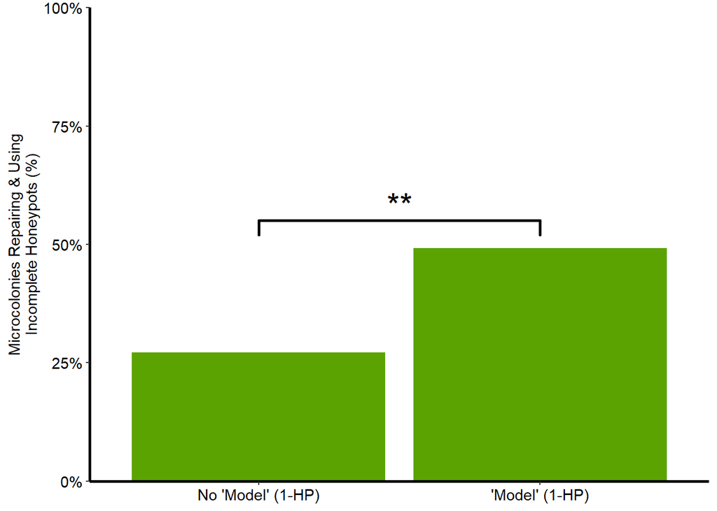

```r
library(stringr)

# Wrap the y-axis label
wrapped_label <- str_wrap("Microcolonies Repairing & Using Incomplete Honeypots (%)", width = 40)

# bar graph with combined results for Groups 1&3 and 2&4
plot1 <- ggplot(exp2data, aes(factor(model), nectar_incomplete_ever)) +
  stat_summary(fun=mean, geom="bar", fill="#5BA300") +
  geom_signif(
    comparisons = list(c("N", "Y")),
    map_signif_level = TRUE,
    y_position = 0.5,
    size = 0.9,
    textsize = 8) +
  scale_y_continuous(labels = scales::percent, limits=c(0,1), expand = c(0, 0)) +
  labs(y = wrapped_label) +
  theme(panel.grid.major = element_blank(),
        panel.grid.minor = element_blank(),
        panel.background = element_blank(),
        axis.line = element_line(colour = "black", size = 1.01),
        axis.text = element_text(color = "black", size = 11),
        axis.title.x = element_blank(),
        axis.title.y = element_text(size = 11),
        text = element_text(family= "Arial")) +
  scale_x_discrete(labels=c("No 'Model' (1-HP)", "'Model' (1-HP)"))
print(plot1)
```